# shiny tutorial 06 - shinydashboard package

2020-04-01T01:10:39+09:00

## 공지

이번에 준비한 튜토리얼은 제 강의를 듣는 과거-현재-미래 수강생분들을 위해 준비한 자료이다. 많은 도움이 되기를 바란다

이번에 준비한 Tutorial 코로나 세계현황을 `Shiny Dashboard`로 만들어 가는 과정을 담았다.

## I. 이전 글 소개

처음 shiny를 접하거나 shiny의 전체 튜토리얼이 궁금한 사람들을 위해 이전 글을 소개한다. - [shiny tutorial 01 - get started](https://chloevan.github.io/r/shiny/tutorial_01/) - [shiny tutorial 02 - Shiny Structure](https://chloevan.github.io/r/shiny/tutorial_02/) - [shiny tutorial 03 - HTML content](https://chloevan.github.io/r/shiny/tutorial_03/) - [shiny tutorial 04 - Shiny Layouts](https://chloevan.github.io/r/shiny/tutorial_04/) - [shiny tutorial 05 - Sharing Apps](https://chloevan.github.io/r/shiny/tutorial_05/)

## II. shinydashboard 패키지의 개요

`HTML content`와 `Layouts` 조작하는 것이 편해지면 대시보드를 만들 수 있다. 그런데, 문제는 대시보드 개발을 처음부터 하는 것과 어느정도 정해진 포맷을 활용하여 작성하는 것은 다르다. 반복해서 말하지만, 데이터분석가가 처음부터 개발해서 `사내 내부용 보고서`를 꼭 작성해서 만들어야 하는가?하는가? 글쎄. 개인적으로 동의하기 어렵다. 핵심적인 내용의 지표만 산출 및 작성 요약하여 보고하는 것이 데이터 분석가의 기본적인 업무이자 핵심적인 업무이기 때문에, 다양한 대시보드를 빠르게 그러나 가독성있게 만드는 것이 중요하다. 어차피, 이러한 대시보드 역시, 시간이 지나면 결국엔 보는 사람만 본다.

`shinydashboard` 패키지와 그리고 다음 장에서 설명할 `flexdashboard` 패키지를 활용하여 대시보드를 빠르게 만들어봄으로써 shiny 개발 & 배포를 빠르게 반복적으로 진행하며 학습하는 것을 권한다.

## III. Get Started

다른 R의 패키지처럼, `shinydashboard` 패키지를 설치한다. `shiny` 패키지가 설치가 되어 있지 않거나 `shiny Version (>=0.11)`이 낮은 경우, 설치 에러가 날 수 있으니 주의 한다.

```
install.packages("shinydashboard")
```

## (1) shinydashboard 구조

Shiny의 기본구조는 `ui`, `server`, `shinyApp`으로 구성되어 있음을 알고 있다. shinydashboard 패키지를 사용시, 이 때의 `ui` 문법이 조금 달라진다. 어렵지는 않다. 그냥 제공하는 함수가 다를 뿐이다.

일단 간단하게 소스와 결과를 확인해 보자! 아래 소스코드를 따라하면서 연습할 때는 `app.R` 파일을 생성한 뒤 아래 코드를 작성하도록 한다.

```r
library(shiny)
library(shinydashboard)
ui <- dashboardPage(
  dashboardHeader(),
  dashboardSidebar(),
  dashboardBody()
)

server <- function(input, output) { }

shinyApp(ui, server)
```

```
##
## Listening on http://127.0.0.1:3474
```

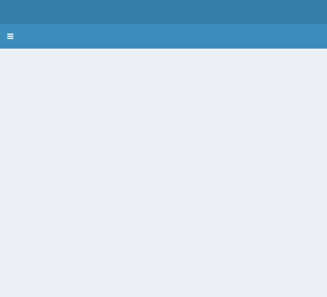

`dashboardPage()` 안에 `Header()`, `Sidebar()`, `Body()`가 만들어진다.

위 대시보드는 `default`로 만들어진 것이고, 여기에서 이제 각각의 구성품을 채워넣는 작업을 할 것이다.

## (1) dashboardHeader()

먼저 제목부터 달아보자.

```r
library(shiny)
library(shinydashboard)

ui <- dashboardPage(
  dashboardHeader(title = "첫번째 대시보드"),
  dashboardSidebar(),
  dashboardBody()
)

server <- function(input, output) { }

shinyApp(ui, server)
```

```
##
## Listening on http://127.0.0.1:4095
```

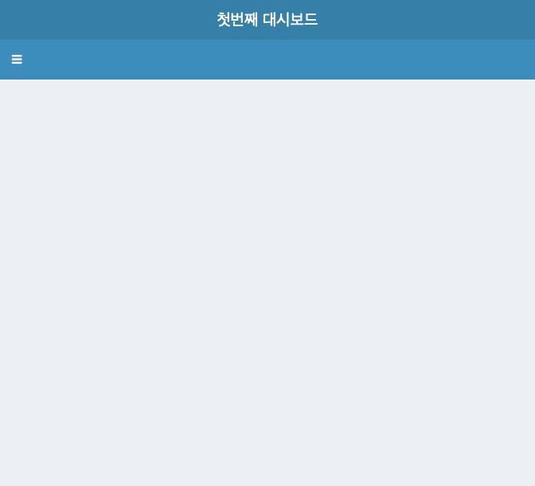

## (2) dashboardSidebar()

Sidebar의 주 활용 용도는 메뉴 구성과 같은 개념으로 파악하면 좋다. 아래 소스코드를 활용해서 실습하기를 바란다.

```r
library(shiny)
library(shinydashboard)

ui <- dashboardPage(
  dashboardHeader(title = "첫번째 대시보드"),
  dashboardSidebar(
    # 사이드바 메뉴 구성
    sidebarMenu(
      menuItem(text = "대시보드", tabName = "dashboard", icon = icon("dashboard")),
      menuItem(text = "위젯", tabName = "widgets", icon = icon("th"))
    )
  ),
  dashboardBody()
)

server <- function(input, output) { }

shinyApp(ui, server)
```

```
##
## Listening on http://127.0.0.1:7315
```

[figure not shown]

`dashboardSidebar()` 안에 `sidebarMenu()` 메뉴 구성을 만든다. 그 이후에 `menuItem()`을 입력하는데, 다양한 `Arguments`들이 있는 것을 확인할 수 있다. 각 `Arguments` 사용 설명서는 `?menuItem`를 실행한 후, 확인하는 것을 추천한다. 각각의 `Arguments`들은 일종의 대시보드 화면을 좀 더 `Interactive`하게 만들어주는 옵션이기 때문에, 다양한 방법으로 시도하는 것을 권유한다.

## (3) dashboardBody()

기존 shiny에서 작업했던 `inputId`, `outputId` 값이 일치한 것을 기억했으면 좋겠다. 마찬가지로 `menuItem() tabName`값은 `Body() tabName`값과 일치해야 한다.

이유는 간단하다. `menuItem`의 각 메뉴들을 클릭할 때마다, 다른 화면이 나타나게끔 하려고 하는 것이 `menuItem`을 사용하는 목적이기 때문이다. 일종의 `Key`값이라고 하면 적정한 표현일까?

아래 소스를 통해서 한번 더 확인해본다. `Body` 안에 들어가는 소스코드도 중요하지만, 여기에서는 `tabName`을 유심히 관찰할 필요가 있다. 처음에 발생하는 에러의 대부분은 `ID`가 일치하지 않아 발생하는 경우가 대부분이다.

```
##
## Listening on http://127.0.0.1:8129
```

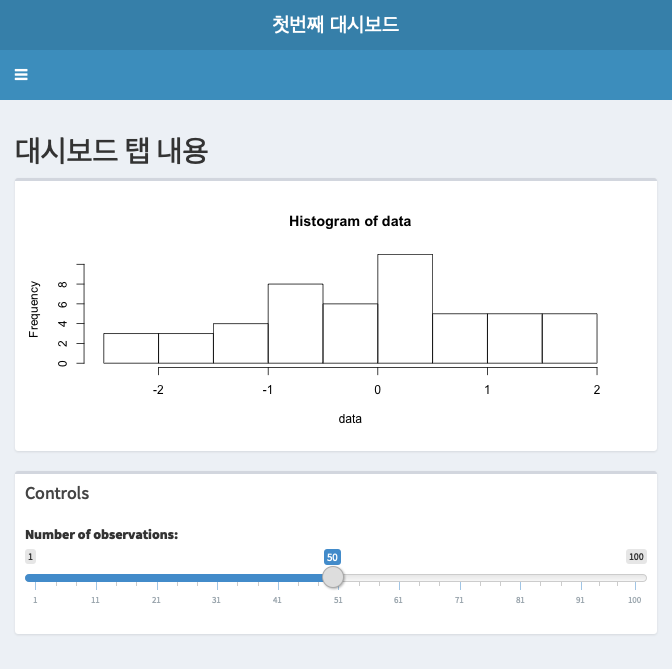

```r
library(shiny)
library(shinydashboard)

ui <- dashboardPage(
  dashboardHeader(title = "첫번째 대시보드"),
  dashboardSidebar(
    # 사이드바 메뉴 구성
    sidebarMenu(
      menuItem(text = "대시보드", tabName = "dashboard", icon = icon("dashboard")),
      menuItem(text = "위젯", tabName = "widgets", icon = icon("th"))
    ) # sidebarMenu
  ), # dashboardSidebar
  dashboardBody(
    tabItems(
      # First tab content
      tabItem(tabName = "dashboard",
        h2("대시보드 탭 내용"),
        fluidRow(
          box(plotOutput("plot1", height = 250)),

          box(
            title = "Controls",
            sliderInput("slider", "Number of observations:", 1, 100, 50)
          ) # box
        ) # fluidRow
      ), # tabItem(tabName = "dashboard")

      # Second tab content
      tabItem(tabName = "widgets",
        h2("위젯 탭 내용")
      ) # tabItem
    ) # tabItems
  ) # dashboardBody
)

server <- function(input, output) {
  set.seed(122)
  histdata <- rnorm(500)

  output$plot1 <- renderPlot({
    data <- histdata[seq_len(input$slider)]
    hist(data)
  })
}

shinyApp(ui, server)
```

`dashboardBody()` – `tabItems` – `tabItem` 순서대로 코드를 작성하는데, 가장 많이 실수하는 곳은 예상할 수 있겠지만 `tabItems`와 `tabItem` 오기하는 것이 많기 때문에 주의 하기 바란다.

## V. 더 알아보기

지금까지 작성한 내용은 매우 기초적인 부분에서만 접근을 한 것이기 때문에, 더 많은 기능은 직접 해봐야 알 수 있다. shinydashboard 패키지에 대한 구체적인 내용들은 [Structure](https://rstudio.github.io/shinydashboard/structure.html), [Apperance](https://rstudio.github.io/shinydashboard/appearance.html) 등을 참조하기를 바란다.

## VI. Sample

`shinydashboard`를 활용한 예제코드를 보면서 `필사` 하는 것을 추천한다. 그리고 전반적인 과정을 이해하면, 그 후에 약간의 코드 수정으로 응용하여 배포하는 것을 권유한다.

- [Twin Cities Buses](https://gallery.shinyapps.io/086-bus-dashboard/)
- [crandash](https://gallery.shinyapps.io/087-crandash/)

## VI. Reference

shinydashboard., (2020). shinydashboard. Retrieved April 1, 2020, from https://rstudio.github.io/shinydashboard/index.html/